```python
import numpy as np
import matplotlib.pyplot as plt
import pandas as pd
import seaborn as sns
%matplotlib inline

# ## Plotly plotting support
# import plotly.plotly as py

import plotly.offline as py
py.init_notebook_mode(connected=True)

import plotly.graph_objs as go
import plotly.figure_factory as ff
import cufflinks as cf

cf.set_config_file(offline=False, world_readable=True, theme='ggplot')
```

# Introduction

In this lecture we examine the process of data cleaning and Exploratory Data Analysis (EDA). Often you will acquire or even be given a collection of data in order to conduct some analysis or answer some questions. The first step in using that data is to ensure that it is in the correct form (cleaned) and that you understand its properties and limitations (EDA). Often as you explore data through EDA you will identify additional transformations (cleaning) that may be required before the data is ready for analysis.

In this notebook we obtain crime data from the city of Berkeley's public records. Ultimately, our goal is to understand policing patterns better but before we get there we must first clean and understand the data.

# Unboxing the Data

We have downloaded some data from the city of Berkeley's open data repositories and placed them in the data folder. The first step to understanding the data is learning a bit about the files.

## How big is the data?

I often like to start my analysis by getting a rough estimate of the size of the data. This will help inform the tools I used and how I view the data. If it is relatively small I might use a text editor or a spreadsheet to look at the data. If it is larger, I might jump to more programmatic exploration or even used distributed computing tools.

The following command lists (`l`) the files with human (`h`) readable file sizes:

```
ls -lh data
```

```python
ls -lh data
```

```
total 13936
-rw-r--r--@ 1 jegonzal  staff   979K Aug 29 11:41 Berkeley_PD_-_Calls_for_Service.csv
-rw-r--r--  1 jegonzal  staff    81B Aug 29 11:28 cvdow.csv
-rw-r--r--@ 1 jegonzal  staff   5.8M Aug 29 11:41 stops.json
```

You may also want to try the file command:

```python
!file data/*
```

```
data/Berkeley_PD_-_Calls_for_Service.csv: ASCII text
data/cvdow.csv:                           ASCII text
data/stops.json:                          UTF-8 Unicode text, with very long lines
```

This command reveals a bit more about the structure of the data.

All the files are relatively small and we could comfortable examine them in your favorite text editors. (Personally, I like *sublime* or *emacs* but others may have a different *vi*ew.).

In listing the files I noticed that the names suggest that they are all text file formats:

- **CSV**: Comma separated values is a very standard table format.
- **JSON**: JavaScript Object Notation is a very standard semi-structured file format used to store nested data.

We will dive into the formats in a moment. However because these are text data I might also want to investigate the number of lines which often correspond to records.

Here I am invoking the shell command via the `!` operator. The `wc` command computes the number of **lines**, **words**, and **characters** in each file:

```python
!wc data/*
```

```
   16497   87732 1002706 data/Berkeley_PD_-_Calls_for_Service.csv
       8       8      81 data/cvdow.csv
   29852  658575 6124111 data/stops.json
   46357  746315 7126898 total
```

If we wanted to learn more about the command we could use the `man` (short for **manual**) command to read the manual page for `wc` (word count).

```python
man wc
```

## What is the format?

We already noticed that the files end in `csv` and `json` which suggests that these are comma separated values and javascript object notation files. However, we can't always rely on the naming as this is only a convention. Often files will have incorrect extensions or no extension at all.

Let's assume that these are text files (and do not contain binary encoded data). We could then use the `head` command to look at the first few lines each file.

```python
!head -n 7 data/Berkeley_PD_-_Calls_for_Service.csv
```

```
CASENO,OFFENSE,EVENTDT,EVENTTM,CVLEGEND,CVDOW,InDbDate,Block_Location,BLKADDR,City,State
17091420,BURGLARY AUTO,07/23/2017 12:00:00 AM,06:00,BURGLARY - VEHICLE,0,08/29/2017 08:28:05 AM,"2500 LE CONTE AVE
Berkeley, CA
(37.876965, -122.260544)",2500 LE CONTE AVE,Berkeley,CA
17020462,THEFT FROM PERSON,04/13/2017 12:00:00 AM,08:45,LARCENY,4,08/29/2017 08:28:00 AM,"2200 SHATTUCK AVE
Berkeley, CA
(37.869363, -122.268028)",2200 SHATTUCK AVE,Berkeley,CA
```

### Observations about `Berkeley_PD_-_Calls_for_Service.csv`?

1. It does appear to be in comma separated value format.
2. First line contains the column headings
3. There are **"quoted"** strings in the `Block_Location` column:

   ```
   "2500 LE CONTE AVE
   Berkeley, CA
   (37.876965, -122.260544)"
   ```

   these are going to be difficult. What are the implications on our earlier word count `wc` calculation?

Examining the rest of the files:

```python
!head -n 5 data/cvdow.csv
```

```
CVDOW,Day
0,Sunday
1,Monday
2,Tuesday
3,Wednesday
```

The `cvdow.csv` file is relatively small. We can use the `cat` command to print out the entire file:

```python
!cat data/cvdow.csv
```

```
CVDOW,Day
0,Sunday
1,Monday
2,Tuesday
3,Wednesday
4,Thursday
5,Friday
6,Saturday
```

Seems like a pretty standard well formatted CSV file.

Finally examining the `stops.json` file:

```python
!head data/stops.json
```

```
{
  "meta" : {
    "view" : {
      "id" : "6e9j-pj9p",
      "name" : "Berkeley PD - Stop Data",
      "attribution" : "Berkeley Police Department",
      "averageRating" : 0,
      "category" : "Public Safety",
      "createdAt" : 1444171604,
      "description" : "This data was extracted from the Department’s Public Safety Server and covers the data beginning January 26, 2015.  On January 26, 2015 the department began collecting data pursuant to General Order B-4 (issued December 31, 2014).  Under that order, officers were required to p…
```

#### Observations?

This appears to be a fairly standard JSON file. We notice that the file appears to contain a description of itself in a field called "meta" (which is presumably short for meta-data). We will come back to this meta data in a moment but first let's quickly discuss the JSON file format.

## A quick note on JSON

[JSON (JavaScript Object Notation)](http://www.json.org) is a common format for exchanging complex structured and semi-structured data.

```
{
    "field1": "value1",
    "field2": ["list", "of", "values"],
    "myfield3": {"is_recursive": true, "a null value": null}
}
```

A few key points:

- JSON is a recursive format in that JSON fields can also contain JSON objects
- JSON closely matches Python Dictionaries:

  ```
  d = {
    "field1": "value1",
    "field2": ["list", "of", "values"],
    "myfield3": {"is_recursive": True, "a null value": None}
  }
  print(d['myfield3'])
  ```

- Very common in web technologies (... JavaScript)
- Many languages have tools for loading and saving JSON objects

# Reading About the Data

This is not always an option as:

1. There may be limited or no documentation.
2. Documentation may be out of date. (How will you know?)

In our case there is documentation for some of the datasets:

1. [Call Data](https://data.cityofberkeley.info/Public-Safety/Berkeley-PD-Calls-for-Service/k2nh-s5h5)
2. [Stop Data](https://data.cityofberkeley.info/Public-Safety/Berkeley-PD-Stop-Data/6e9j-pj9p)

Here are summaries of the fields in the data:

### Calls Data

[figure not shown]

### Stop Data

[figure not shown]

# Loading the Data

We will now attempt to load the data into python. We will be using the Pandas dataframe library for basic tabular data analysis. Fortunately, the Pandas library has some relatively sophisticated functions for loading data.

```python
cvdow = pd.read_csv("data/cvdow.csv")
cvdow
```

|  | CVDOW | Day |
| --- | --- | --- |
| 0 | 0 | Sunday |
| 1 | 1 | Monday |
| 2 | 2 | Tuesday |
| 3 | 3 | Wednesday |
| 4 | 4 | Thursday |
| 5 | 5 | Friday |
| 6 | 6 | Saturday |

### Preliminary observations on the data?

```python
cvdow.set_index("CVDOW", inplace=True)
```

Looks like a **dictionary** that defines the meaning of values for a field stored in another table.

## Loading the Calls Data

Because the file appears to be a relatively well formatted CSV we will attempt to load it directly and allow the Pandas Library to deduce column headers. (Always check that first row and column look correct after loading.)

```python
calls = pd.read_csv("data/Berkeley_PD_-_Calls_for_Service.csv")
calls.head()
```

|  | CASENO | OFFENSE | EVENTDT | EVENTTM | CVLEGEND | CVDOW | InDbDate | Block_Location | BLKADDR | City | State |
| --- | --- | --- | --- | --- | --- | --- | --- | --- | --- | --- | --- |
| 0 | 17091420 | BURGLARY AUTO | 07/23/2017 12:00:00 AM | 06:00 | BURGLARY - VEHICLE | 0 | 08/29/2017 08:28:05 AM | 2500 LE CONTE AVE\nBerkeley, CA\n(37.876965, -... | 2500 LE CONTE AVE | Berkeley | CA |
| 1 | 17020462 | THEFT FROM PERSON | 04/13/2017 12:00:00 AM | 08:45 | LARCENY | 4 | 08/29/2017 08:28:00 AM | 2200 SHATTUCK AVE\nBerkeley, CA\n(37.869363, -... | 2200 SHATTUCK AVE | Berkeley | CA |
| 2 | 17050275 | BURGLARY AUTO | 08/24/2017 12:00:00 AM | 18:30 | BURGLARY - VEHICLE | 4 | 08/29/2017 08:28:06 AM | 200 UNIVERSITY AVE\nBerkeley, CA\n(37.865491, ... | 200 UNIVERSITY AVE | Berkeley | CA |
| 3 | 17019145 | GUN/WEAPON | 04/06/2017 12:00:00 AM | 17:30 | WEAPONS OFFENSE | 4 | 08/29/2017 08:27:59 AM | 1900 SEVENTH ST\nBerkeley, CA\n(37.869318, -12... | 1900 SEVENTH ST | Berkeley | CA |
| 4 | 17044993 | VEHICLE STOLEN | 08/01/2017 12:00:00 AM | 18:00 | MOTOR VEHICLE THEFT | 2 | 08/29/2017 08:28:05 AM | 100 PARKSIDE DR\nBerkeley, CA\n(37.854247, -12... | 100 PARKSIDE DR | Berkeley | CA |

How many records did we get?

```python
len(calls)
```

```
5508
```

### Preliminary observations on the data?

1. `EVENTDT` -- Contain the incorrect time stamp
2. `EVENTTM` -- Contains the time in 24 hour format (What timezone?)
3. `InDbDate` -- Appears to be correctly formatted and appears pretty consistent in time.
4. **`Block_Location` -- Errr, what a mess! newline characters, and Geocoordinates all merged!! Fortunately, this field was "quoted" otherwise we would have had trouble parsing the file. (why?)**
5. `BLKADDR` -- This appears to be the address in Block Location.
6. `City` and `State` seem redundant given this is supposed to be the city of Berkeley dataset.

### Checking that City and State are Redundant

We notice that there are city and state columns. Since this is supposed to be data for the city of Berkeley these columns appear to be redundant. Let's quickly compute the number of occurences of unique values for these two columns.

```python
calls.groupby(["City", "State"]).count()
```

| City | State | CASENO | OFFENSE | EVENTDT | EVENTTM | CVLEGEND | CVDOW | InDbDate | Block_Location | BLKADDR |
| --- | --- | --- | --- | --- | --- | --- | --- | --- | --- | --- |
| Berkeley | CA | 5508 | 5508 | 5508 | 5508 | 5508 | 5508 | 5508 | 5508 | 5481 |

# Cleaning Block Location

The block location contains the GPS coordinates and I would like to use these to analyze the location of each request. Let's try to extract the GPS coordinates using regular expressions:

```python
calls_lat_lon = (
    # Remove newlines
    calls['Block_Location'].str.replace("\n", "\t")
    # Extract Lat and Lon using regular expression
    .str.extract(".*\((?P<Lat>\d*\.\d*)\, (?P<Lon>-?\d*.\d*)\)",expand=True)
)
calls_lat_lon.head()
```

|  | Lat | Lon |
| --- | --- | --- |
| 0 | 37.876965 | -122.260544 |
| 1 | 37.869363 | -122.268028 |
| 2 | 37.865491 | -122.310065 |
| 3 | 37.869318 | -122.296984 |
| 4 | 37.854247 | -122.24375 |

```python
# Remove Lat and Lon if they already existed before (reproducible)
calls.drop(["Lat", "Lon"], axis=1, inplace=True, errors="ignore")
# Join in the the latitude and longitude data
calls = calls.join(calls_lat_lon)
calls.head()
```

|  | CASENO | OFFENSE | EVENTDT | EVENTTM | CVLEGEND | CVDOW | InDbDate | Block_Location | BLKADDR | City | State | Lat | Lon |
| --- | --- | --- | --- | --- | --- | --- | --- | --- | --- | --- | --- | --- | --- |
| 0 | 17091420 | BURGLARY AUTO | 07/23/2017 12:00:00 AM | 06:00 | BURGLARY - VEHICLE | 0 | 08/29/2017 08:28:05 AM | 2500 LE CONTE AVE\nBerkeley, CA\n(37.876965, -... | 2500 LE CONTE AVE | Berkeley | CA | 37.876965 | -122.260544 |
| 1 | 17020462 | THEFT FROM PERSON | 04/13/2017 12:00:00 AM | 08:45 | LARCENY | 4 | 08/29/2017 08:28:00 AM | 2200 SHATTUCK AVE\nBerkeley, CA\n(37.869363, -... | 2200 SHATTUCK AVE | Berkeley | CA | 37.869363 | -122.268028 |
| 2 | 17050275 | BURGLARY AUTO | 08/24/2017 12:00:00 AM | 18:30 | BURGLARY - VEHICLE | 4 | 08/29/2017 08:28:06 AM | 200 UNIVERSITY AVE\nBerkeley, CA\n(37.865491, ... | 200 UNIVERSITY AVE | Berkeley | CA | 37.865491 | -122.310065 |
| 3 | 17019145 | GUN/WEAPON | 04/06/2017 12:00:00 AM | 17:30 | WEAPONS OFFENSE | 4 | 08/29/2017 08:27:59 AM | 1900 SEVENTH ST\nBerkeley, CA\n(37.869318, -12... | 1900 SEVENTH ST | Berkeley | CA | 37.869318 | -122.296984 |
| 4 | 17044993 | VEHICLE STOLEN | 08/01/2017 12:00:00 AM | 18:00 | MOTOR VEHICLE THEFT | 2 | 08/29/2017 08:28:05 AM | 100 PARKSIDE DR\nBerkeley, CA\n(37.854247, -12... | 100 PARKSIDE DR | Berkeley | CA | 37.854247 | -122.24375 |

## Loading the JSON Data

```python
import json

with open("data/stops.json", "rb") as f:
    stops_json = json.load(f)
```

We can list the keys to determine what data is stored in the object.

```python
stops_json.keys()
```

```
dict_keys(['meta', 'data'])
```

## Digging into Meta Data

Meta data is information about the data.

```python
stops_json['meta'].keys()
```

```
dict_keys(['view'])
```

```python
stops_json['meta']['view'].keys()
```

```
dict_keys(['id', 'name', 'attribution', 'averageRating', 'category', 'createdAt', 'description', 'displayType', 'downloadCount', 'hideFromCatalog', 'hideFromDataJson', 'indexUpdatedAt', 'newBackend', 'numberOfComments', 'oid', 'provenance', 'publicationAppendEnabled', 'publicationDate', 'publication…
```

```python
print(stops_json['meta']['view']['description'])
```

```
This data was extracted from the Department’s Public Safety Server and covers the data beginning January 26, 2015.  On January 26, 2015 the department began collecting data pursuant to General Order B-4 (issued December 31, 2014).  Under that order, officers were required to provide certain data aft…

Address data has been changed from a specific address, where applicable, and listed as the block where the incident occurred.  Disposition codes were entered by officers who made the stop.  These codes included the person(s) race, gender, age (range), reason for the stop, enforcement action taken, a…

The officers of the Berkeley Police Department are prohibited from biased based policing, which is defined as any police-initiated action that relies on the race, ethnicity, or national origin rather than the behavior of an individual or information that leads the police to a particular individual w…
```

```python
for c in stops_json['meta']['view']['columns']:
    print(c["name"], "----------->")
    if "description" in c:
        print(c["description"])
    print("======================================\n")
```

```
sid ----------->
======================================

id ----------->
======================================

position ----------->
======================================

created_at ----------->
======================================

created_meta ----------->
======================================

updated_at ----------->
======================================

updated_meta ----------->
======================================

meta ----------->
======================================

Incident Number ----------->
Number of incident created by Computer Aided Dispatch (CAD) program
======================================

Call Date/Time ----------->
Date and time of the incident/stop
======================================

Location ----------->
General location of the incident/stop
======================================

Incident Type ----------->
This is the occurred incident type created in the CAD program.  A code signifies a traffic stop (T), suspicious vehicle stop (1196), pedestrian stop (1194) and bicycle stop (1194B).
======================================

```

[output cut: 20 more lines]

```
IN - Incident report
FC - Field Card
CO - Collision investigation report
MH - Emergency Psychiatric Evaluation
TOW - Impounded vehicle
0 or 00000 – Officer made a stop of more than five persons
======================================

Location - Latitude ----------->
General latitude of the call.  This data is only uploaded after January 2017
======================================

Location - Longitude ----------->
General longitude of the call.  This data is only uploaded after January 2017.
======================================
```

```python
stops_json['data'][0:2]
```

```
[[1,
  '29A1B912-A0A9-4431-ADC9-FB375809C32E',
  1,
  1444146408,
  '932858',
  1444146408,
  '932858',
  None,
  '2015-00004825',
  '2015-01-26T00:10:00',
  'SAN PABLO AVE / MARIN AVE',
  'T',
  'M',
  None,
  None],
 [2,
  '1644D161-1113-4C4F-BB2E-BF780E7AE73E',
  2,
  1444146408,
  '932858',
  1444146408,
  '932858',
  None,
  '2015-00004829',
  '2015-01-26T00:50:00',
  'SAN PABLO AVE / CHANNING WAY',
  'T',
  'M',
  None,
  None]]
```

## Building a Dataframe from JSON

In the following block of code we:

1. Translate the JSON records into a dataframe
2. Remove columns that have no metadata description. This would be a bad idea in general but here we remove these columns since the above analysis suggests that they are unlikely to contain useful information.
3. Examine the top of the table

```python
# Load the data from JSON and assign column titles
stops = pd.DataFrame(
    stops_json['data'],
    columns=[c['name'] for c in stops_json['meta']['view']['columns']])

# Remove columns that are missing descriptions
bad_cols = [c['name'] for c in stops_json['meta']['view']['columns'] if "description" not in c]

# Note we make changes in place
#  This is generally a bad idea but since the stops dataframe is
#  created in the same cell it will be ok.
stops.drop(bad_cols, axis=1, inplace=True)


stops.head()
```

|  | Incident Number | Call Date/Time | Location | Incident Type | Dispositions | Location - Latitude | Location - Longitude |
| --- | --- | --- | --- | --- | --- | --- | --- |
| 0 | 2015-00004825 | 2015-01-26T00:10:00 | SAN PABLO AVE / MARIN AVE | T | M | None | None |
| 1 | 2015-00004829 | 2015-01-26T00:50:00 | SAN PABLO AVE / CHANNING WAY | T | M | None | None |
| 2 | 2015-00004831 | 2015-01-26T01:03:00 | UNIVERSITY AVE / NINTH ST | T | M | None | None |
| 3 | 2015-00004848 | 2015-01-26T07:16:00 | 2000 BLOCK BERKELEY WAY | 1194 | BM4ICN | None | None |
| 4 | 2015-00004849 | 2015-01-26T07:43:00 | 1700 BLOCK SAN PABLO AVE | 1194 | BM4ICN | None | None |

## Preliminary Observations

What do we observe so far?

We observe:

1. The `Incident Number` appears to have the year encoded in it.
2. The `Call Date/Time` Field looks to be formatted in YYYY-MM-DDTHH:MM:SS. I am guessing T means "Time".
3. `Incident Type` has some weird coding. This is define in the column meta data: *This is the occurred incident type created in the CAD program. A code signifies a traffic stop (T), suspicious vehicle stop (1196), pedestrian stop (1194) and bicycle stop (1194B).*

# EDA

Now that we have loaded our various data files. Let's try to understand a bit more about the data by examining properties of individual fields.

## EDA on the Calls Data

```python
calls.head()
```

|  | CASENO | OFFENSE | EVENTDT | EVENTTM | CVLEGEND | CVDOW | InDbDate | Block_Location | BLKADDR | City | State | Lat | Lon |
| --- | --- | --- | --- | --- | --- | --- | --- | --- | --- | --- | --- | --- | --- |
| 0 | 17091420 | BURGLARY AUTO | 07/23/2017 12:00:00 AM | 06:00 | BURGLARY - VEHICLE | 0 | 08/29/2017 08:28:05 AM | 2500 LE CONTE AVE\nBerkeley, CA\n(37.876965, -... | 2500 LE CONTE AVE | Berkeley | CA | 37.876965 | -122.260544 |
| 1 | 17020462 | THEFT FROM PERSON | 04/13/2017 12:00:00 AM | 08:45 | LARCENY | 4 | 08/29/2017 08:28:00 AM | 2200 SHATTUCK AVE\nBerkeley, CA\n(37.869363, -... | 2200 SHATTUCK AVE | Berkeley | CA | 37.869363 | -122.268028 |
| 2 | 17050275 | BURGLARY AUTO | 08/24/2017 12:00:00 AM | 18:30 | BURGLARY - VEHICLE | 4 | 08/29/2017 08:28:06 AM | 200 UNIVERSITY AVE\nBerkeley, CA\n(37.865491, ... | 200 UNIVERSITY AVE | Berkeley | CA | 37.865491 | -122.310065 |
| 3 | 17019145 | GUN/WEAPON | 04/06/2017 12:00:00 AM | 17:30 | WEAPONS OFFENSE | 4 | 08/29/2017 08:27:59 AM | 1900 SEVENTH ST\nBerkeley, CA\n(37.869318, -12... | 1900 SEVENTH ST | Berkeley | CA | 37.869318 | -122.296984 |
| 4 | 17044993 | VEHICLE STOLEN | 08/01/2017 12:00:00 AM | 18:00 | MOTOR VEHICLE THEFT | 2 | 08/29/2017 08:28:05 AM | 100 PARKSIDE DR\nBerkeley, CA\n(37.854247, -12... | 100 PARKSIDE DR | Berkeley | CA | 37.854247 | -122.24375 |

### Checking that City and State are Redundant

We notice that there are city and state columns. Since this is supposed to be data for the city of Berkeley these columns appear to be redundant. Let's quickly compute the number of occurences of unique values for these two columns.

```python
calls.groupby(["City", "State"]).count()
```

| City | State | CASENO | OFFENSE | EVENTDT | EVENTTM | CVLEGEND | CVDOW | InDbDate | Block_Location | BLKADDR | Lat | Lon |
| --- | --- | --- | --- | --- | --- | --- | --- | --- | --- | --- | --- | --- |
| Berkeley | CA | 5508 | 5508 | 5508 | 5508 | 5508 | 5508 | 5508 | 5508 | 5481 | 5229 | 5229 |

### Are Case Numbers unique?

Case numbers are probably used internally to track individual cases and my reference other data we don't have access to. However, it is possible that multiple calls could be associated with the same case. Let's see if the case numbers are all unique.

```python
print("There are", len(calls['CASENO'].unique()), "unique case numbers.")
print("There are", len(calls), "calls in the table.")
```

```
There are 5508 unique case numbers.
There are 5508 calls in the table.
```

Are case numbers assigned consecutively.

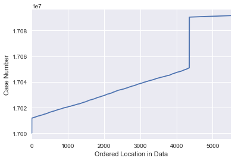

```python
calls['CASENO'].sort_values().reset_index(drop=True).plot()
plt.xlabel("Ordered Location in Data")
plt.ylabel("Case Number")
```

```python
calls['CASENO'].sort_values().reset_index(drop=True).iplot(
    xTitle="Ordered Location in Data",
    yTitle="Case Number")
```

[interactive chart not shown]

```python
calls['CASENO'].iplot(kind="hist",bins=30)
```

[interactive chart not shown]

### What might we be observing?

One possible explanation is that case numbers were assigned consecutively and then sampled uniformly at different rates for two different periods. We will be able to understand this better by looking at the dates on the cases.

### Examining the Date

Given the weird behavior with the case numbers let's dig into the date in which events were recorded. Notice in this data we have several pieces of date/time information (this is not uncommon):

1. **`EVENTDT`**: This contains the date the event took place. While it has time information the time appears to be `00:00:00`.
2. **`EVENTTM`**: This contains the time at which the event took place.
3. **`InDbDate`**: This appears to be the date at which the data was entered in the database.

```python
calls.head(3)
```

|  | CASENO | OFFENSE | EVENTDT | EVENTTM | CVLEGEND | CVDOW | InDbDate | Block_Location | BLKADDR | City | State | Lat | Lon |
| --- | --- | --- | --- | --- | --- | --- | --- | --- | --- | --- | --- | --- | --- |
| 0 | 17091420 | BURGLARY AUTO | 07/23/2017 12:00:00 AM | 06:00 | BURGLARY - VEHICLE | 0 | 08/29/2017 08:28:05 AM | 2500 LE CONTE AVE\nBerkeley, CA\n(37.876965, -... | 2500 LE CONTE AVE | Berkeley | CA | 37.876965 | -122.260544 |
| 1 | 17020462 | THEFT FROM PERSON | 04/13/2017 12:00:00 AM | 08:45 | LARCENY | 4 | 08/29/2017 08:28:00 AM | 2200 SHATTUCK AVE\nBerkeley, CA\n(37.869363, -... | 2200 SHATTUCK AVE | Berkeley | CA | 37.869363 | -122.268028 |
| 2 | 17050275 | BURGLARY AUTO | 08/24/2017 12:00:00 AM | 18:30 | BURGLARY - VEHICLE | 4 | 08/29/2017 08:28:06 AM | 200 UNIVERSITY AVE\nBerkeley, CA\n(37.865491, ... | 200 UNIVERSITY AVE | Berkeley | CA | 37.865491 | -122.310065 |

When Pandas loads more complex fields like dates it typically will load them as strings:

```python
calls["EVENTDT"][0]
```

```
'07/23/2017 12:00:00 AM'
```

We will want to convert these to dates. Pandas has a fairly sophisticated function `pd.to_datetime` which is capable of guessing reasonable conversions of dates to date objects.

```python
dates = pd.to_datetime(calls["EVENTDT"])
```

We can verify that the translations worked by looking at a few dates:

```python
pd.DataFrame(dict(transformed=dates, original=calls["EVENTDT"])).head()
```

|  | original | transformed |
| --- | --- | --- |
| 0 | 07/23/2017 12:00:00 AM | 2017-07-23 |
| 1 | 04/13/2017 12:00:00 AM | 2017-04-13 |
| 2 | 08/24/2017 12:00:00 AM | 2017-08-24 |
| 3 | 04/06/2017 12:00:00 AM | 2017-04-06 |
| 4 | 08/01/2017 12:00:00 AM | 2017-08-01 |

We can also extract the time field:

```python
times = pd.to_datetime(calls["EVENTTM"]).dt.time
times.head()
```

```
0    06:00:00
1    08:45:00
2    18:30:00
3    17:30:00
4    18:00:00
Name: EVENTTM, dtype: object
```

To combine the correct date and correct time field we use the built-in python datetime combine function.

```python
from datetime import datetime
timestamps = pd.to_datetime(pd.concat([dates, times], axis=1).apply(
    lambda r: datetime.combine(r['EVENTDT'], r['EVENTTM']), axis=1))
timestamps.head()
```

```
0   2017-07-23 06:00:00
1   2017-04-13 08:45:00
2   2017-08-24 18:30:00
3   2017-04-06 17:30:00
4   2017-08-01 18:00:00
dtype: datetime64[ns]
```

We now updated calls to contain this additional informations:

```python
calls['timestamp'] = timestamps
calls.head()
```

|  | CASENO | OFFENSE | EVENTDT | EVENTTM | CVLEGEND | CVDOW | InDbDate | Block_Location | BLKADDR | City | State | Lat | Lon | timestamp |
| --- | --- | --- | --- | --- | --- | --- | --- | --- | --- | --- | --- | --- | --- | --- |
| 0 | 17091420 | BURGLARY AUTO | 07/23/2017 12:00:00 AM | 06:00 | BURGLARY - VEHICLE | 0 | 08/29/2017 08:28:05 AM | 2500 LE CONTE AVE\nBerkeley, CA\n(37.876965, -... | 2500 LE CONTE AVE | Berkeley | CA | 37.876965 | -122.260544 | 2017-07-23 06:00:00 |
| 1 | 17020462 | THEFT FROM PERSON | 04/13/2017 12:00:00 AM | 08:45 | LARCENY | 4 | 08/29/2017 08:28:00 AM | 2200 SHATTUCK AVE\nBerkeley, CA\n(37.869363, -... | 2200 SHATTUCK AVE | Berkeley | CA | 37.869363 | -122.268028 | 2017-04-13 08:45:00 |
| 2 | 17050275 | BURGLARY AUTO | 08/24/2017 12:00:00 AM | 18:30 | BURGLARY - VEHICLE | 4 | 08/29/2017 08:28:06 AM | 200 UNIVERSITY AVE\nBerkeley, CA\n(37.865491, ... | 200 UNIVERSITY AVE | Berkeley | CA | 37.865491 | -122.310065 | 2017-08-24 18:30:00 |
| 3 | 17019145 | GUN/WEAPON | 04/06/2017 12:00:00 AM | 17:30 | WEAPONS OFFENSE | 4 | 08/29/2017 08:27:59 AM | 1900 SEVENTH ST\nBerkeley, CA\n(37.869318, -12... | 1900 SEVENTH ST | Berkeley | CA | 37.869318 | -122.296984 | 2017-04-06 17:30:00 |
| 4 | 17044993 | VEHICLE STOLEN | 08/01/2017 12:00:00 AM | 18:00 | MOTOR VEHICLE THEFT | 2 | 08/29/2017 08:28:05 AM | 100 PARKSIDE DR\nBerkeley, CA\n(37.854247, -12... | 100 PARKSIDE DR | Berkeley | CA | 37.854247 | -122.24375 | 2017-08-01 18:00:00 |

### What time range does the data represent

```python
calls['timestamp'].min()
```

```
Timestamp('2017-03-02 02:00:00')
```

```python
calls['timestamp'].max()
```

```
Timestamp('2017-08-28 09:35:00')
```

### Are there any temporal patterns

Do more calls occur on a particular day of the week?

```python
calls['timestamp'].dt.dayofweek.value_counts().iplot(kind='bar', yTitle="Count")
```

[interactive chart not shown]

```python
help(pd.Series.dt.dayofweek)
```

```
Help on property:

    The day of the week with Monday=0, Sunday=6
```

Modified version with dates:

```python
dow = ["Monday", "Tuesday", "Wednesday", "Thursday", "Friday", "Saturday", "Sunday"]
(pd.concat([pd.Series(dow, name="dow"), calls['timestamp'].dt.dayofweek.value_counts()],axis=1)
     .set_index("dow")
     .iplot(kind="bar", yTitle="Count"))
```

[interactive chart not shown]

How about temporal patterns within a day?

```python
ts = calls['timestamp']
minute_in_day = ts.dt.hour * 60 + ts.dt.minute
py.iplot(ff.create_distplot([minute_in_day],group_labels=["minute"],bin_size=60))
```

[interactive chart not shown]

### Observations?

In the above plot we see the standard pattern of limited activity early in the morning around here 6:00AM.

How could we segment this data to get something a bit more interesting:

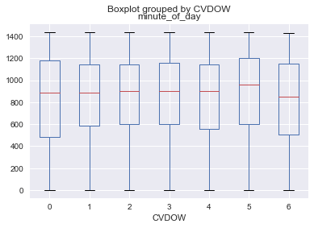

```python
calls['minute_of_day'] = minute_in_day
calls.boxplot('minute_of_day', by='CVDOW')
```

```python
groups = calls.groupby("CVDOW")
py.iplot([go.Box(y=df["minute_of_day"], name=str(cvdow.loc[i][0])) for (i, df) in groups])
```

[interactive chart not shown]

```python
# fig = ff.create_violin(calls, data_header='minute_of_day', group_header='CVDOW')
# py.iplot(fig, filename='Multiple Violins')
```

### Examining the Event

```python
calls.head()
```

|  | CASENO | OFFENSE | EVENTDT | EVENTTM | CVLEGEND | CVDOW | InDbDate | Block_Location | BLKADDR | City | State | Lat | Lon | timestamp | minute_of_day |
| --- | --- | --- | --- | --- | --- | --- | --- | --- | --- | --- | --- | --- | --- | --- | --- |
| 0 | 17091420 | BURGLARY AUTO | 07/23/2017 12:00:00 AM | 06:00 | BURGLARY - VEHICLE | 0 | 08/29/2017 08:28:05 AM | 2500 LE CONTE AVE\nBerkeley, CA\n(37.876965, -... | 2500 LE CONTE AVE | Berkeley | CA | 37.876965 | -122.260544 | 2017-07-23 06:00:00 | 360 |
| 1 | 17020462 | THEFT FROM PERSON | 04/13/2017 12:00:00 AM | 08:45 | LARCENY | 4 | 08/29/2017 08:28:00 AM | 2200 SHATTUCK AVE\nBerkeley, CA\n(37.869363, -... | 2200 SHATTUCK AVE | Berkeley | CA | 37.869363 | -122.268028 | 2017-04-13 08:45:00 | 525 |
| 2 | 17050275 | BURGLARY AUTO | 08/24/2017 12:00:00 AM | 18:30 | BURGLARY - VEHICLE | 4 | 08/29/2017 08:28:06 AM | 200 UNIVERSITY AVE\nBerkeley, CA\n(37.865491, ... | 200 UNIVERSITY AVE | Berkeley | CA | 37.865491 | -122.310065 | 2017-08-24 18:30:00 | 1110 |
| 3 | 17019145 | GUN/WEAPON | 04/06/2017 12:00:00 AM | 17:30 | WEAPONS OFFENSE | 4 | 08/29/2017 08:27:59 AM | 1900 SEVENTH ST\nBerkeley, CA\n(37.869318, -12... | 1900 SEVENTH ST | Berkeley | CA | 37.869318 | -122.296984 | 2017-04-06 17:30:00 | 1050 |
| 4 | 17044993 | VEHICLE STOLEN | 08/01/2017 12:00:00 AM | 18:00 | MOTOR VEHICLE THEFT | 2 | 08/29/2017 08:28:05 AM | 100 PARKSIDE DR\nBerkeley, CA\n(37.854247, -12... | 100 PARKSIDE DR | Berkeley | CA | 37.854247 | -122.24375 | 2017-08-01 18:00:00 | 1080 |

```python
calls['OFFENSE'].value_counts().iplot(kind="bar")
```

[interactive chart not shown]

```python
calls['CVLEGEND'].value_counts().iplot(kind="bar")
```

[interactive chart not shown]

View the crime time periods broken down by crime type:

```python
boxes = [(len(df), go.Box(y=df["minute_of_day"], name=i)) for (i, df) in calls.groupby("CVLEGEND")]
py.iplot([r[1] for r in sorted(boxes, key=lambda x:x[0], reverse=True)])
```

[interactive chart not shown]

## Examining Location information

```python
missing_lat_lon = calls[calls[['Lat', 'Lon']].isnull().any(axis=1)]
missing_lat_lon['CVLEGEND'].value_counts()
```

```
DRUG VIOLATION            53
LARCENY                   39
BURGLARY - VEHICLE        30
DISORDERLY CONDUCT        29
ASSAULT                   25
MOTOR VEHICLE THEFT       16
FRAUD                     13
BURGLARY - RESIDENTIAL    11
VANDALISM                  9
SEX CRIME                  9
LIQUOR LAW VIOLATION       9
ROBBERY                    8
MISSING PERSON             7
FAMILY OFFENSE             6
WEAPONS OFFENSE            6
BURGLARY - COMMERCIAL      3
ALL OTHER OFFENSES         3
LARCENY - FROM VEHICLE     3
Name: CVLEGEND, dtype: int64
```

```python
(missing_lat_lon['CVLEGEND'].value_counts() / calls['CVLEGEND'].value_counts()).sort_values(ascending=False)
```

```
ALL OTHER OFFENSES        0.333333
SEX CRIME                 0.180000
DRUG VIOLATION            0.161585
WEAPONS OFFENSE           0.077922
MISSING PERSON            0.072917
ASSAULT                   0.071023
DISORDERLY CONDUCT        0.069880
LIQUOR LAW VIOLATION      0.061224
MOTOR VEHICLE THEFT       0.051948
FRAUD                     0.050000
FAMILY OFFENSE            0.046154
ROBBERY                   0.042781
BURGLARY - RESIDENTIAL    0.040146
LARCENY                   0.035390
BURGLARY - VEHICLE        0.029383
BURGLARY - COMMERCIAL     0.028846
LARCENY - FROM VEHICLE    0.021429
VANDALISM                 0.020548
ARSON                          NaN
HOMICIDE                       NaN
KIDNAPPING                     NaN
NOISE VIOLATION                NaN
RECOVERED VEHICLE              NaN
Name: CVLEGEND, dtype: float64
```

```python
ts = calls['timestamp']

py.iplot(ff.create_distplot([calls['timestamp'].dt.dayofyear,
                             missing_lat_lon['timestamp'].dt.dayofyear],
                            group_labels=["all data", "missing lat-lon"],bin_size=2))
```

[interactive chart not shown]

```python
!pip install --upgrade folium
import folium
print(folium.__version__, "should be at least 0.3.0")
```

```
0.3.0 should be at least 0.3.0
```

```python
import folium
import folium.plugins # The Folium Javascript Map Library

SF_COORDINATES = (37.87, -122.28)
sf_map = folium.Map(location=SF_COORDINATES, zoom_start=13)
locs = calls[['Lat', 'Lon']].astype('float').dropna().as_matrix()
sf_map.add_child(folium.plugins.HeatMap(locs, radius = 10))


sf_map
```

[interactive chart not shown]

```python
# cluster = folium.MarkerCluster()
# has_lat_lon = calls[['Lat', 'Lon']].astype('float').notnull().all(axis=1)
# for id, row in calls[has_lat_lon].iterrows():
#     cluster.add_child(folium.Marker(location=[float(row['Lat']), float(row['Lon'])],
#                                     popup=row['CVLEGEND']))
```

```python
# sf_map = folium.Map(location=SF_COORDINATES, zoom_start=13)
# sf_map.add_child(cluster)
# sf_map
```

```python
# sf_map
```